# R for Play: When Data Meets Creativity

Exploring how R can make everyday life more fun and personal

L — Data Analyst, University of Oxford

## Why This Talk

- We often think of R as something we use for work or research.
- But what if R could also be fun, creative, and personal?
- Today, I’ll share a few of my pet projects that made my everyday life more playful.

> “Play is the highest form of research.” – Albert Einstein

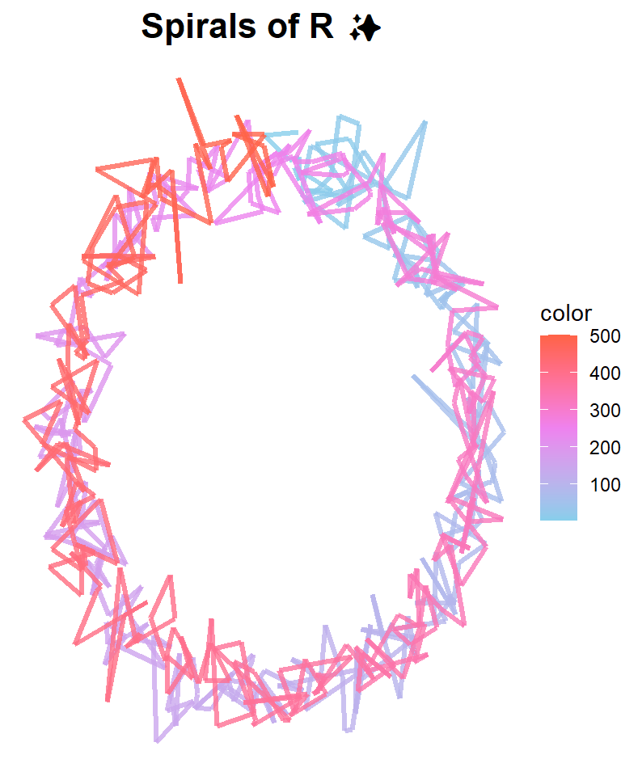

```r
library(ggplot2)

set.seed(42)
n <- 500
df <- data.frame(
  x = sin(seq(0, 4*pi, length.out = n)) + rnorm(n, sd = 0.1),
  y = cos(seq(0, 4*pi, length.out = n)) + rnorm(n, sd = 0.1),
  color = seq_len(n)
)

ggplot(df, aes(x, y, color = color)) +
  geom_path(size = 1.2, alpha = 0.8) +
  scale_color_gradientn(colors = c("skyblue", "violet", "tomato")) +
  theme_void() +
  ggtitle("Spirals of R ✨") +
  theme(
    plot.title = element_text(hjust = 0.5, face = "bold", size = 16)
  )
```

## Why This Talk

- We often think of R as something we use for work or research.
- But what if R could also be fun, creative, and personal?
- Today, I’ll share a few of my pet projects that made my everyday life more playful.

> “Play is the highest form of research.” – Albert Einstein

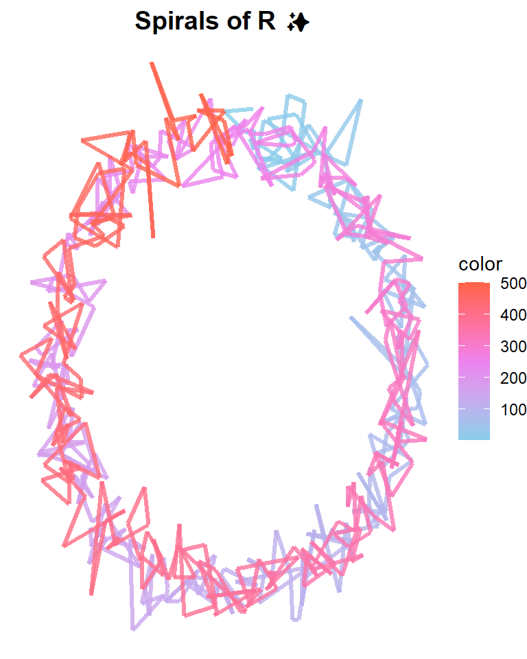

```r
library(ggplot2)

set.seed(42)
n <- 500
df <- data.frame(
  x = sin(seq(0, 4*pi, length.out = n)) + rnorm(n, sd = 0.1),
  y = cos(seq(0, 4*pi, length.out = n)) + rnorm(n, sd = 0.1),
  color = seq_len(n)
)

ggplot(df, aes(x, y, color = color)) +
  geom_path(size = 1.2, alpha = 0.8) +
  scale_color_gradientn(colors = c("skyblue", "violet", "tomato")) +
  theme_void() +
  ggtitle("Spirals of R ✨") +
  theme(plot.title = element_text(hjust = 0.5, face = "bold", size = 14))
```

## What ‘Play’ Means Here

- “Play” = experimenting, trying things without deadlines.
- Exploring what R can do outside of work or school.
- Learning through curiosity and creativity.

## Pet Project 1 – Tidytuesday Adventures

- I use #TidyTuesday to explore new datasets * .
- It’s a great way to practice data wrangling, visualisation, and storytelling.

## Pet Project 2 – Personal Menu Generator 🍜

- When I moved to a new city, I built a script to help me choose what to eat.
- It randomly picked meals from a list, saving time and making it fun!
- You can wrap it in a simple Shiny app or use it from the console!

## Pet Project 3 – Gift Selector 🎁

- I made a small data frame of gift ideas and built a random picker.
- Great for birthdays, holidays, or when I wanted to treat myself!

## Pet Project 4 – Designing Pride Flags with R 🏳🌈

- I used R to design pride flag patterns for my home.
- Packages: {ggplot2}, {grid}, {ggpattern}.

## Pet Project 5 – R on My Phone 📱

- Installed R on my phone via Termux / Posit Cloud.
- Handy for testing small code snippets anywhere!
- Example use cases:
  - Quick data summaries
  - Random number generators
  - Small visual experiments

## Pet Project 6: Shiny App to Explore LGBTQ+ Movies in the UK 🎬🏳🌈

- Aim: celebrate queer cinema and discover films people might have missed!
- Built a Shiny app that lets users explore data on LGBTQ+ movies shown in UK cinemas or available on streaming.
- Users can filter by:
  - Year, genre, director, and representation type
  - IMDb rating or audience score

Visuals:

- Interactive scatterplots (ggplotly or {plotly})
- Word clouds of film themes or directors
- Data sourced from public film datasets and APIs (e.g., IMDb or TMDb).

## Curating and Sharing: My WeAreR-Ladies Week 💜

- I had the chance to curate **@WeAreRLadies**, the rotating Twitter/X account that features R users worldwide.
- To prepare, I built an **R Markdown file** full of ideas and topics I wanted to share.
- Throughout the week I:
  - Explored new `#TidyTuesday` datasets 🎨
  - Shared interesting packages — like **{tidylog}**, my wrangling co-pilot 🧭
  - Posted reflections on learning, creativity, and community
- This experience reminded me that *sharing what you learn is also a form of play* —  
  it keeps curiosity alive and builds connection across the R world.

```r
library(dplyr)
library(tidylog)  # My co-pilot!

mtcars %>%
  filter(mpg > 25) %>%
  select(mpg, hp)
```

```
                mpg  hp
Fiat 128       32.4  66
Honda Civic    30.4  52
Toyota Corolla 33.9  65
Fiat X1-9      27.3  66
Porsche 914-2  26.0  91
Lotus Europa   30.4 113
```

## Why Play Matters

- Playful R projects helped me:
  - Learn new packages and tricks.
  - Stay motivated and curious.
  - See R as part of everyday life, not just work.
- Fun projects build real skills.

## What You Can Try Next

- Join `#TidyTuesday` and pick a dataset that interests you.
- Try making generative art with {ggplot2}.
- Analyse your Spotify, Strava, or sleep data.
- Build something personal: a random quote generator or meal picker.

“If it brings you joy, it’s worth coding.”

## Closing Thoughts

- R is not just for work — it’s for life, art, and play.
- Be curious. Experiment. Share.
- Thank you!

## Bonus Slide: Behind the Scenes 😂

Fun bugs and “oops” moments.

Reminder: every playful project starts messy!